# Markers Segregation Test

Author

Affiliation

João Vitor Sanches Calvo

Department of Genetics, ESALQ-USP

# Exercise

**Using the provided dataset, describe the hypothesis test and perform the segregation tests in each marker. Using five randomly picked markers, plot the theoretical distribution and the corresponding significance level and p-value.**

The dataset is composed of 189 individuals and 1145 markers. As the individuals belong to a RILs population, only homozygous genotypes are expected, at a 1:1 ratio. To analyse the segregation, it could be used the $\chi²$ test, where $N_o$ and $N_e$ represents the observed and expected counts in each genotype class.

$$\chi² = \sum \frac{(N_o - N_e)²}{N_e}$$

For each marker, this test will evaluate if the observed marker segregation follows the expected pattern, in this case, a 1:1 ratio:

$$H_0: \text{The observed genotypes follow a 1:1 ratio}$$
$$H_1: \text{The observed genotypes deviate from a 1:1 ratio}$$

As this is a multiple comparison problem, Bonferroni or FDR corrections should be considered. By using Bonferroni, to obtain a global significance level $\alpha$ , the p-value considered in each comparison should be: $\alpha^* = \alpha / m$ , where $m$ stands for the total number of comparisons. This is a very conservative correction, usually resulting in a lot of false-negative cases (not rejecting $H_0$ when it should). On the other hand, FDR correction is a less conservative approach, where the risk of some false-positives is accepted in order to reduce the number of false negatives. In this method, the significance threshold starts very strict with the smallest p-values, and then gradually increases for the larger ones.

```r
# Loading packages
library(dplyr)
library(readr)
library(ggplot2)

# Import dataset
data = read_csv("Z009.csv")
data = data |> select(1:(ncol(data) - 38))

# Remove heterozygotes
data[data == 1] = NA

# Count genoytpe classes for each marker
observed = apply(data[,-1], 2, function(col) {
  table(factor(col, levels = c(0,2)))})
marker_data <- data.frame(
  n_0 = observed["0", ],
  n_2 = observed["2", ])

# Chi-sq test
marker_data$p_value <- apply(marker_data[,c("n_0","n_2")], 1,
                        function(x) chisq.test(x, p=c(0.5,0.5))$p.value)

# Levels of Significance
n_tests <- nrow(marker_data) #number of tests
p_bon <- 0.05 / n_tests

marker_data$signif_pvalue <- marker_data$p_value <= 0.05 # No correction

marker_data$signif_bonf <- marker_data$p_value <= p_bon # Bonferroni correction

marker_data$p_fdr <- p.adjust(marker_data$p_value, method = "BH") # FDR correction
marker_data$signif_fdr <- marker_data$p_fdr <= 0.05

# Counting
paste("Markers deviating from 1:1 ratio:")
paste("Without correcting p-value -", sum(marker_data$signif_pvalue))
paste("Bonferroni correction -", sum(marker_data$signif_bonf))
paste("FDR correction -", sum(marker_data$signif_fdr))
```

```
[1] "Markers deviating from 1:1 ratio:"
[1] "Without correcting p-value - 248"
[1] "Bonferroni correction - 31"
[1] "FDR correction - 138"
```

As expected, without any multiple test correction, a larger number of markers rejects $H_0$ , due to the higher number of false positives. This occurs because we are applying a per-test significance level of $\alpha^* = 0.05$, which inflates the global significance level beyond 0.05.

When applying Bonferroni correction, which is a highly conservative method, fewer comparisons results in $H_0$ rejection. This happens because the method is designed to minimize the probability of false positives cases. However, there is a trade-off between the false positives and false negatives. As a result, some markers that truly deviate from the expected 1:1 ratio may not be identified, and therefore, are classified as non-significant (false negatives).

Finally, as explained above, FDR correction provides a balance between controlling false positives and maintaining statistical power. By allowing a controlled probability of false positives, it reduces the number of false negatives compared to Bonferroni.

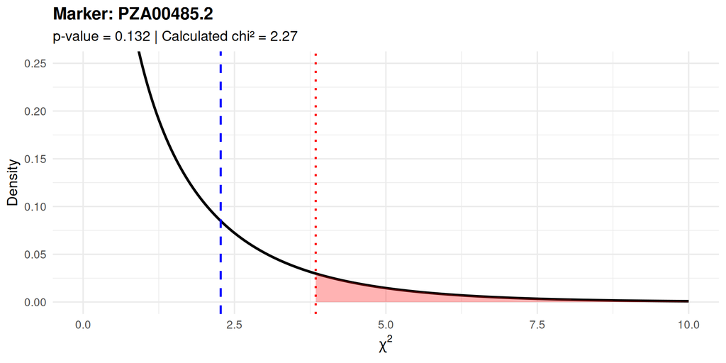

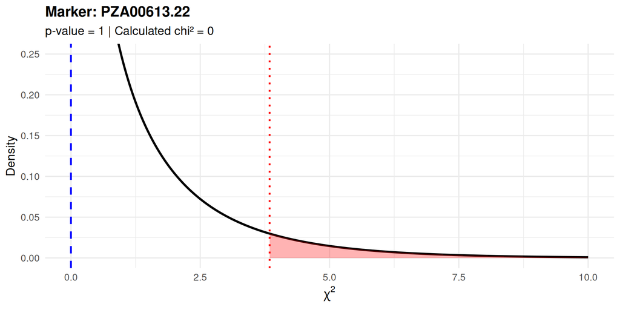

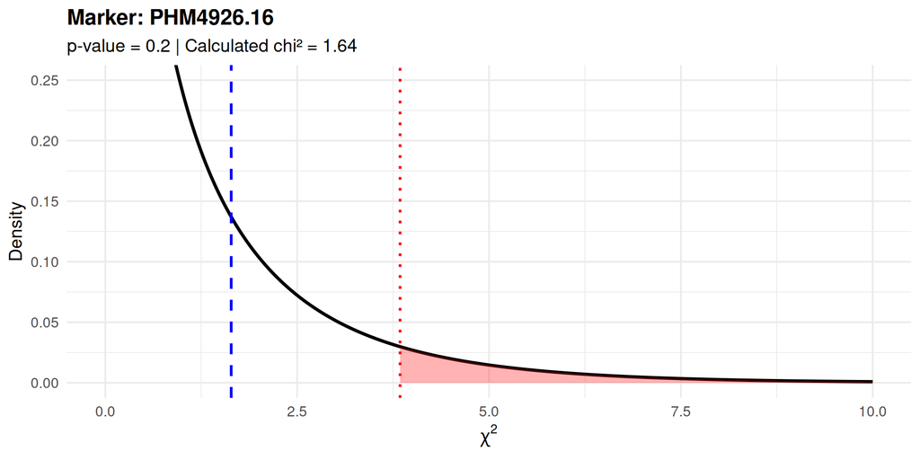

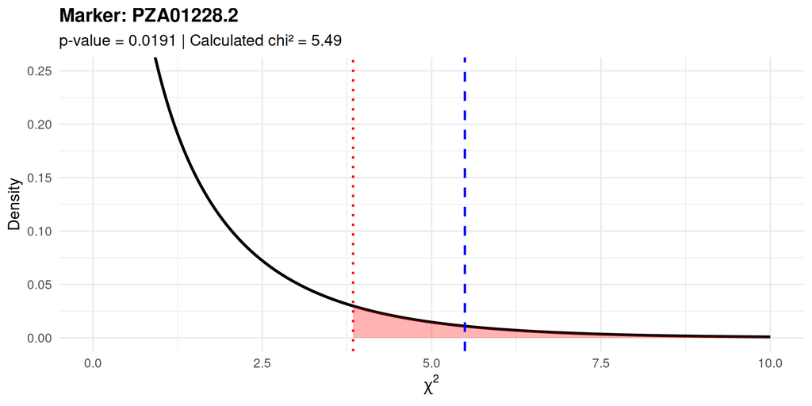

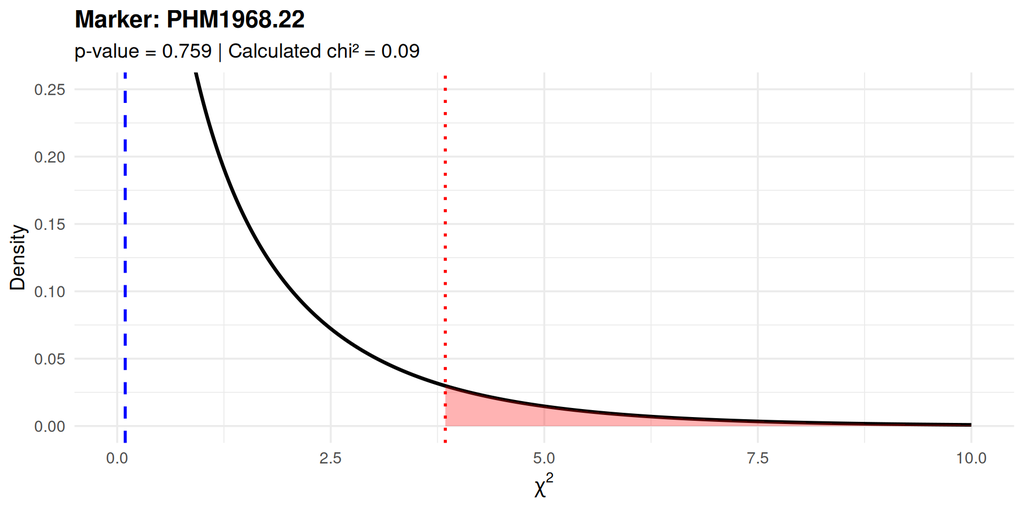

```r
# Plot function
plot_chisq <- function(n0, n2, marker_name, y_max) {

  # Calculating X²
  obs <- c(n0, n2)
  n <- sum(obs)
  expected <- c(0.5, 0.5) * n
  chisq_stat <- sum((obs - expected)^2 / expected)

  # Calculating p-value and significance region
  p_val <- pchisq(chisq_stat, df = 1, lower.tail = FALSE)
  crit <- qchisq(0.95, df = 1)

  # Plotting data
  df <- data.frame(x = seq(0, 10, length.out = 1000))
  df$y <- dchisq(df$x, df = 1)
  ggplot(df, aes(x, y)) +
    geom_line(linewidth = 1.2) +
    geom_ribbon(data = subset(df, x >= crit),
        aes(ymax = y), ymin = 0, fill = "red", alpha = 0.3) +
    geom_vline(xintercept = chisq_stat,linetype = "dashed",linewidth = 1, color = "blue") +
    geom_vline(xintercept = crit,linetype = "dotted",linewidth = 1, color = "red") +
    labs(title = paste("Marker:", marker_name),subtitle = paste(
        "p-value =", signif(p_val, 3),"| Calculated chi² =", round(chisq_stat, 2)),
      x = expression(chi^2),y = "Density") +
    coord_cartesian(ylim = c(0, y_max)) +
    theme_minimal(base_size = 14) +
    theme(plot.title = element_text(face = "bold"))
}

# Running for 5 markers
set.seed(17)
markers_sel <- sample(rownames(marker_data), 5)
par(mfrow = c(2,3))
for(m in markers_sel){
  print(plot_chisq(marker_data[m, "n_0"],marker_data[m, "n_2"],m, y_max=0.25))}
```

In the graphics above, the theoretical distrbution of $\chi²_{(1)}$ is shown, with the blue line representing the calculated $\chi²$ for the marker (which delimits the p-value area). The red area represents the significance region area, where the null hypothesis should be rejected. For simplicity, $\alpha = 00.5$ (without multiple testing correction) is considered in the plots.

It can be seen that for the 5 sampled markers, the only one where the calculated $\chi²$ (blue line) is bigger than the critical $\chi²$ (red line), is **PZA01228.2**. In this case, the null hypothesis is rejected, meaning that this marker deviates from 1:1 ration, when considering $\alpha = 00.5$ (without multiple testing correction). When applying correction methods, the red area gets smaller, becoming more difficult to reject $H_0$.